# ExpoRiskR: Exposure-aware Multi-Omics Risk Modeling

Prem Prashant Chaudhary

22 December 2025

#### Package

ExpoRiskR 0.99.0

# 1 Overview

`ExpoRiskR` provides tools for exposure-aware multi-omics risk modeling in translational and environmental health studies.

This vignette demonstrates a compact, end-to-end workflow on simulated data:

- simulate exposure + multi-omics blocks
- align sample identifiers across blocks
- preprocess blocks
- build an exposure-adjusted microbe–metabolite network
- generate six user-facing figures

To keep vignette build time low on Bioconductor build servers, we use modest settings (e.g., limited `max_pairs`, small bootstrap count, and a relaxed FDR threshold). Users can increase these parameters for real analyses.

# 2 Load package

```r
library(ExpoRiskR)
```

# 3 1. Simulate example data

We generate a small toy dataset consisting of:

- `E`: exposures (continuous covariates)
- `X`: microbiome-like positive features
- `Y`: metabolome-like positive features
- `outcome`: binary phenotype

```r
d <- generate_dummy_exporisk(seed = 1)
str(d, max.level = 1)
```

```
## List of 4
##  $ microbiome: num [1:120, 1:50] 0.366 3.989 0.457 0.211 1.658 ...
##   ..- attr(*, "dimnames")=List of 2
##  $ metabolome: num [1:120, 1:80] 2.144 5.118 1.389 0.615 0.156 ...
##   ..- attr(*, "dimnames")=List of 2
##  $ exposures : num [1:120, 1:10] -0.626 0.184 -0.836 1.595 0.33 ...
##   ..- attr(*, "dimnames")=List of 2
##  $ meta      :'data.frame':  120 obs. of  2 variables:
```

# 4 2. Align and preprocess

## 4.1 2.1 Align sample IDs

Alignment ensures that all blocks have the same samples in the same order.

```r
al <- align_omics(
  microbiome = d$microbiome,
  metabolome = d$metabolome,
  exposures  = d$exposures,
  meta       = d$meta,
  id_col     = "sample_id",
  strict     = TRUE
)
```

## 4.2 2.2 Preprocess blocks

Preprocessing returns numeric matrices with consistent rownames:

- `X`: samples × microbes
- `Y`: samples × metabolites
- `E`: samples × exposures

```r
pr <- prep_omics(al$microbiome, al$metabolome, al$exposures)

X <- pr$X
Y <- pr$Y
E <- pr$E

outcome <- d$meta$outcome
names(outcome) <- d$meta$sample_id

c(
  n_samples = nrow(X),
  n_microbes = ncol(X),
  n_metabolites = ncol(Y),
  n_exposures = ncol(E)
)
```

```
##     n_samples    n_microbes n_metabolites   n_exposures
##           120            50            80            10
```

# 5 3. Build an exposure-adjusted network

## 5.1 3.1 Model definition

For each microbe–metabolite pair, the package fits an exposure-adjusted regression model:

$$\text{metabolite} \sim \text{microbe} + \text{exposures} (+ \text{covariates})$$

Edges represent microbe–metabolite associations *after adjusting for exposures*. The resulting graph is bipartite: nodes are microbes and metabolites (exposures are not nodes).

## 5.2 3.2 Fit network

To keep runtime low in a vignette, we test a limited number of pairs (`max_pairs`) and use a relaxed FDR threshold so an illustrative network is typically non-empty.

```r
net <- build_exposure_network(
  X = X, Y = Y, E = E,
  fdr = 0.8,
  max_pairs = 1500,
  seed = 1
)

nrow(net$edges)
```

```
## [1] 76
```

# 6 4. Visualizations

## 6.1 4.1 Exposure-adjusted microbe–metabolite network

Edge width reflects the magnitude of the estimated association (|beta|), while edge color indicates sign (positive vs. negative). Layout weights use |beta| for robustness.

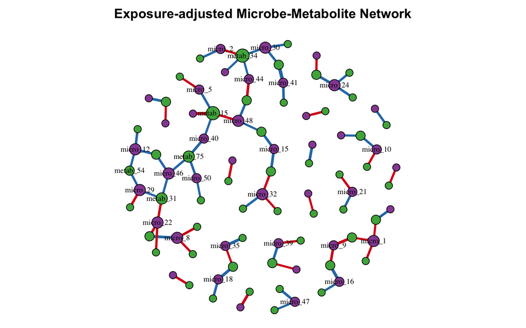

Figure 1: Figure 1: Exposure-adjusted microbe–metabolite network  
Nodes represent microbes and metabolites (bipartite graph). Edges represent microbe effects on metabolites after adjusting for exposures; edge width scales with |beta| and color indicates sign.

```r
plot_exposure_network(net)
```

## 6.2 4.2 Exposure ranking

The exposure ranking summarizes which exposure variables appear most influential, based on their contribution to exposure-adjusted association patterns.

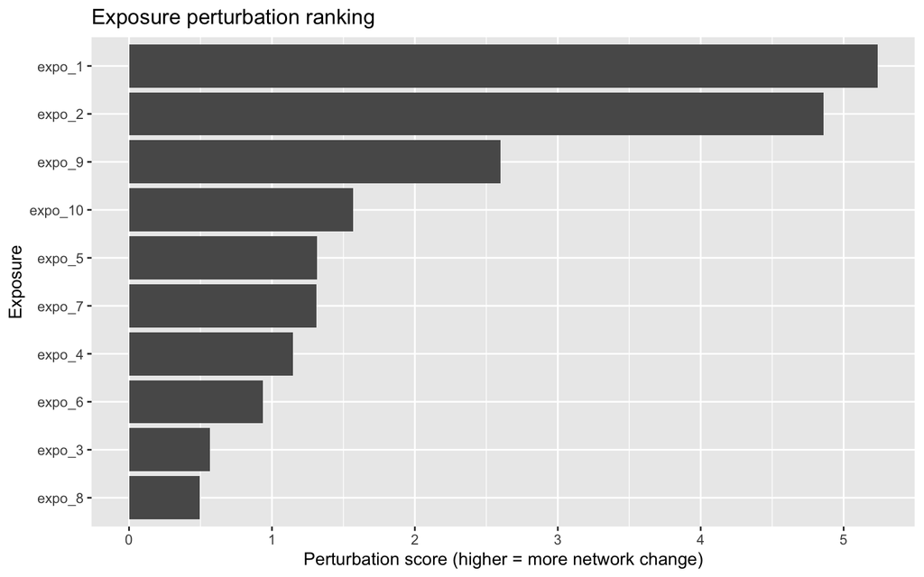

Figure 2: Figure 2: Exposure ranking  
Exposures are ordered by their aggregate perturbation score computed from exposure-adjusted microbe–metabolite associations in the simulated dataset.

```r
scores <- exposure_perturbation_score(
  X = X, Y = Y, E = E,
  fdr = 0.8,
  max_pairs = 1500,
  seed = 1
)

print(plot_exposure_ranking(scores, top_n = 15))
```

## 6.3 4.3 Network stability

Stability assesses how reproducible the inferred edges are under resampling. We use a small number of bootstrap replicates for vignette speed.

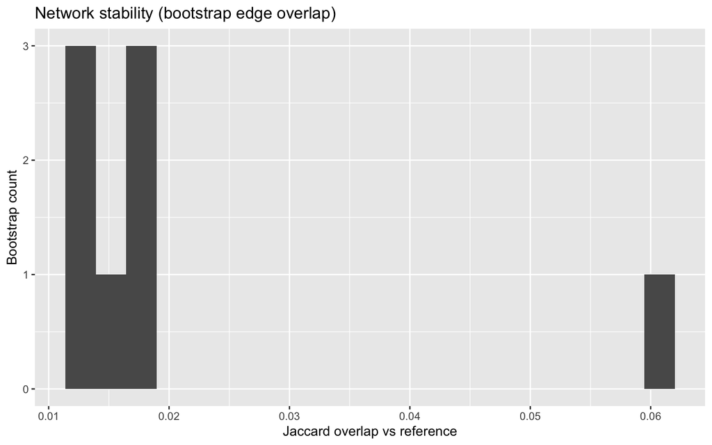

Figure 3: Figure 3: Network stability under bootstrap resampling  
For vignette speed, a small number of bootstrap replicates is used; increase `n_boot` for more stable estimates in real analyses.

```r
print(plot_network_stability(
  X = X, Y = Y, E = E,
  n_boot = 8,
  fdr = 0.8,
  max_pairs = 1000,
  seed = 1
))
```

## 6.4 4.4 Risk ROC curve

The ROC curve illustrates discrimination performance for a simple risk model derived from the exposure-adjusted associations.

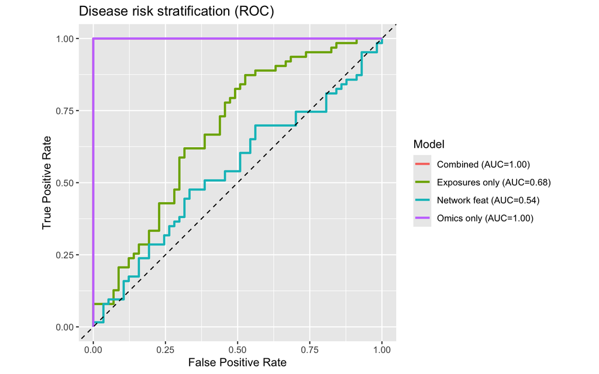

Figure 4: Figure 4: Risk ROC curve for a simple risk model derived from exposure-adjusted associations  
This is a demonstration on simulated data; results should not be interpreted as biological findings.

```r
print(plot_risk_roc(
  X = X, Y = Y, E = E,
  outcome = outcome,
  edges = net$edges,
  top_edges = 80
))
```

## 6.5 4.5 Exposure feature importance

This plot summarizes exposure variables that are most associated with the simulated outcome under a simple risk modeling step. This is intended as a lightweight illustration for users.

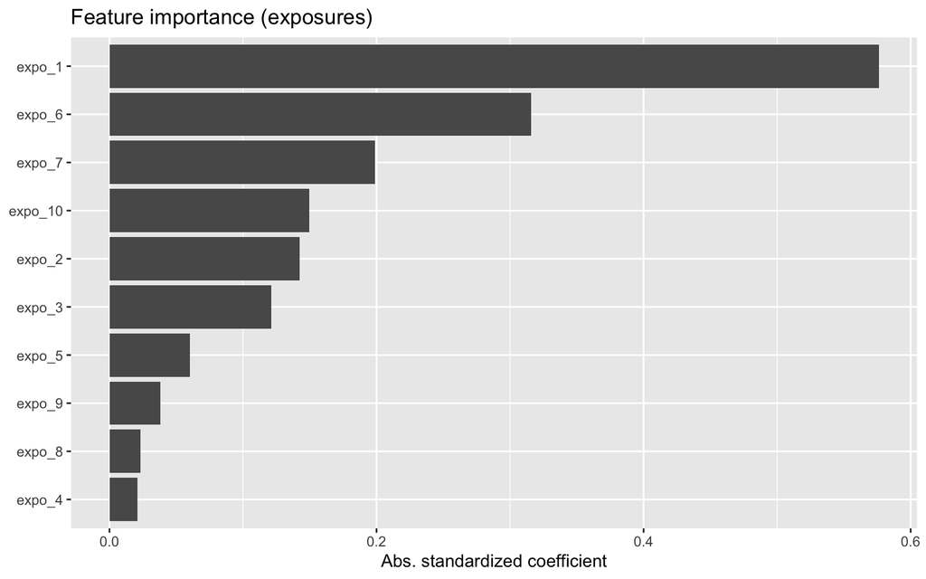

Figure 5: Figure 5: Exposure feature importance for the simulated outcome  
This is a lightweight illustration on simulated data; increase sample size and use domain-specific covariates for real analyses.

```r
print(plot_feature_importance(
  E = E,
  outcome = outcome,
  top_n = 15
))
```

## 6.6 4.6 Individual risk profile

This plot shows a per-sample view of the most influential exposure features for one subject.

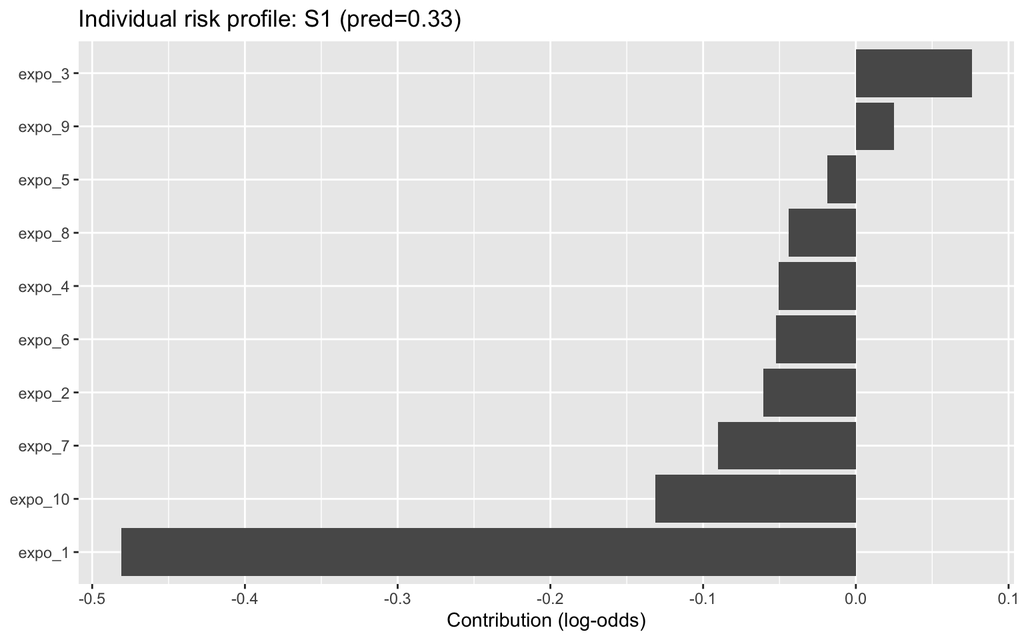

Figure 6: Figure 6: Individual risk profile for a single sample (based on exposures)  
The plot highlights the top exposure features contributing to the sample’s risk score in the simulated dataset.

```r
sid <- rownames(E)[1]
print(plot_individual_risk_profile(
  sample_id = sid,
  E = E,
  outcome = outcome,
  top_n = 12
))
```